# BCO_only_genomic_analysis

Max Cummins

2023-04-10

## File summary

A GitHub repository available at https://github.com/maxlcummins/bonechook contains all scripts and files required to rerun analysis detailed in this document.

Below are the files associated with this research project and report.

### Genomic data

Genomic data was generated using snakemake using the following [snakefile](https://github.com/maxlcummins/pipelord/tree/main/workflow/Snakefile).

### Mashtree

We also generated a mashtree in our QC step, but we will now generate another with only the ones which passed QC.

Now we generate the tree consisting of the BCO samples we filtered for in our QC script. These samples are different from the full BCO cohort as they:

- Are limited to one sample per bird
- Are only sourced from bone sites

Now we run our pangenomics workflow to generate our phylogeny and pangenome for our bone nondupe cohort (with AVC).

Now we run it again for our FH isolates, and FH ST117, ST95, ST69 and ST57

## Genomic analysis

After downloading all of the resulting files from the remote server we are ready to begin our QC.

## Collection breakdown

We will start by producing some figures relating to the collection composition:

### Breakdown by year

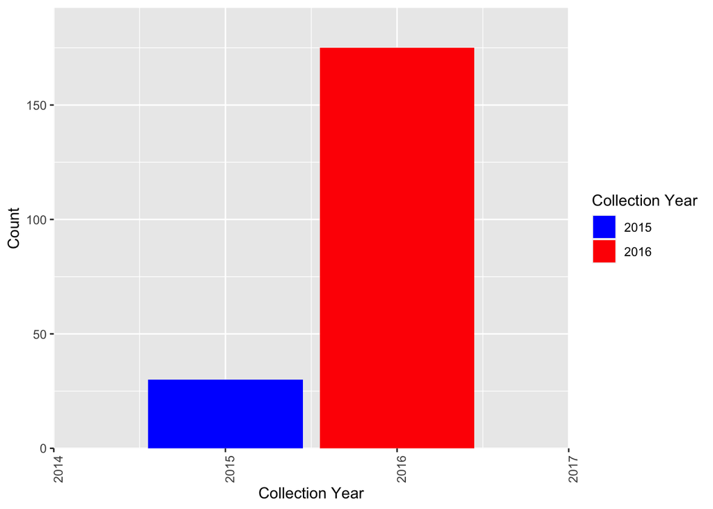

## IncF RST analysis

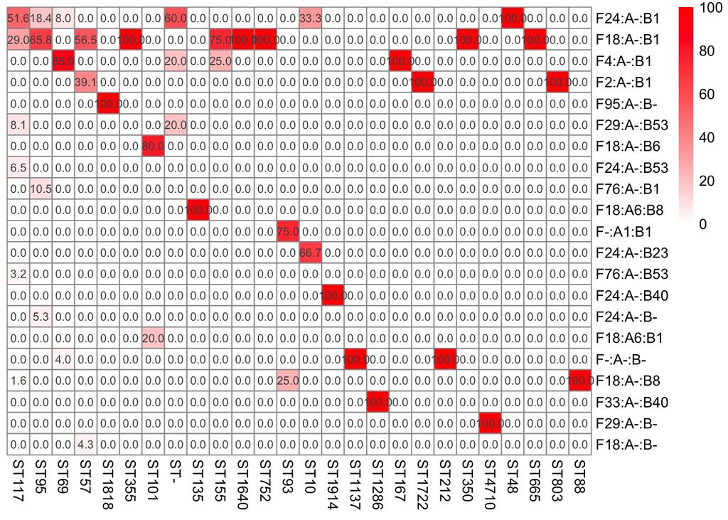

```r
pMLST <- read_delim("analysis/pMLST.txt",
    delim = "\t", escape_double = FALSE,
    trim_ws = TRUE,
    show_col_types = FALSE)

pMLST <- pMLST %>% pivot_wider(id_cols = 'name', names_from = 'pMLST_scheme', values_from = 'pMLST')

genometa <- left_join(genometa, pMLST) %>% mutate(incf = str_replace(incf, pattern = 'C4', replacement = 'F18'))

ST_counts <- genometa %>% group_by(ST) %>% summarise(total = n())

ColV_plas <- genometa %>% group_by(incf, ColV) %>% summarise(total = n())

genometa %>% group_by(ST, incf) %>% summarise(counts = n()) %>% arrange(desc(counts)) %>% inner_join(ST_counts, by = "ST") %>% mutate(perc = round((counts/total)*100, digits = 2)) %>% mutate(ST = paste0("ST",ST)) %>% pivot_wider(id_cols = incf, names_from = ST, values_from = perc) %>% column_to_rownames("incf") %>%  mutate(across(everything(), ~ replace_na(., 0)))%>% pheatmap(display_numbers = T, number_format = "%.01f", color=colorRampPalette(c("white", "red"))(100), cluster_rows = FALSE, cluster_cols = FALSE)
```

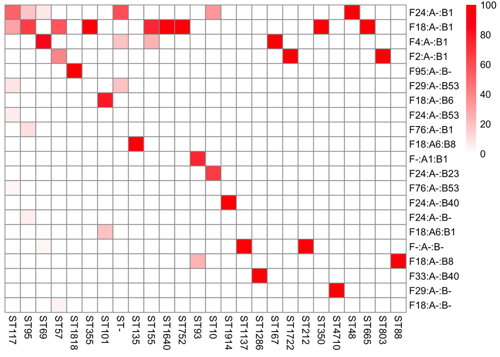

```r
genometa %>% group_by(ST, incf) %>% summarise(counts = n()) %>% arrange(desc(counts)) %>% inner_join(ST_counts, by = "ST") %>% mutate(perc = round((counts/total)*100, digits = 2)) %>% mutate(ST = paste0("ST",ST)) %>% pivot_wider(id_cols = incf, names_from = ST, values_from = perc) %>% column_to_rownames("incf") %>%  mutate(across(everything(), ~ replace_na(., 0)))%>% pheatmap(color=colorRampPalette(c("white", "red"))(100), cluster_rows = FALSE, cluster_cols = FALSE)
```

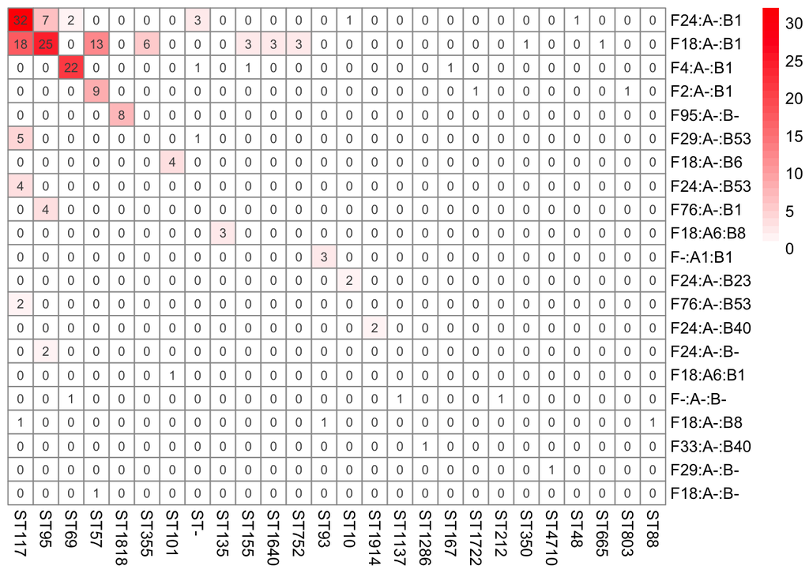

```r
genometa %>% group_by(ST, incf) %>% summarise(counts = n()) %>% arrange(desc(counts)) %>% inner_join(ST_counts, by = "ST") %>% mutate(ST = paste0("ST",ST)) %>% pivot_wider(id_cols = incf, names_from = ST, values_from = counts) %>% column_to_rownames("incf") %>%  mutate(across(everything(), ~ replace_na(., 0)))%>% pheatmap(display_numbers = T, number_format = "%.0f", color=colorRampPalette(c("white", "red"))(32), cluster_rows = FALSE, cluster_cols = FALSE)
```

```r
genometa %>% group_by(ST, incf) %>% summarise(counts = n()) %>% arrange(desc(counts)) %>% inner_join(ST_counts, by = "ST") %>% mutate(ST = paste0("ST",ST)) %>% pivot_wider(id_cols = incf, names_from = ST, values_from = counts) %>% column_to_rownames("incf") %>%  mutate(across(everything(), ~ replace_na(., 0))) %>% as.data.frame() %>% write_delim("delims/IncF_RST_counts.txt", delim = "\t")
```

```r
library(VennDiagram)

#cMake the plot
venn.diagram(
  x = list(
    genometa %>% filter(Collection =="BCO") %>% dplyr::select(ST) %>% unlist(),
    genometa %>% filter(Collection =="AVC") %>% dplyr::select(ST) %>% unlist()
    ),
  category.names = c("BCO", "AVC"),
  filename = 'venn.png',
  output = TRUE ,
          imagetype="png" ,
          height = 480 ,
          width = 480 ,
          resolution = 300,
          compression = "lzw",
          lwd = 1,
          col=c("#440154ff", '#21908dff'),
          fill = c(alpha("#440154ff",0.3), alpha('#21908dff',0.3)),
          cex = 0.5,
          fontfamily = "sans",
          cat.cex = 0.3,
          cat.default.pos = "outer",
          cat.pos = c(-27, 27),
          cat.dist = c(0.055, 0.055),
          cat.fontfamily = "sans",
          cat.col = c("#440154ff", '#21908dff')
        )
```

```
## [1] 1
```

```r
library(ggpubr)

count_sites_by_ST <- genometa %>% filter(Collection == "BCO") %>% group_by(ST, Bird_Gross_Necropsy_ID) %>% summarise(counts = n()) %>% mutate(ST = paste0("ST", ST))

ST_by_clermontype <- genometa %>% group_by(ST, Clermont_type) %>% summarise(counts = n())

ST_by_clermontype <- ST_by_clermontype %>%
        group_by(ST) %>%
        filter(counts == max(counts)) %>%
        arrange(ST,Clermont_type, counts) %>%
        dplyr::select(-counts) %>%
        mutate(ST = paste0("ST", ST))

count_sites_by_ST <- left_join(count_sites_by_ST, ST_by_clermontype) %>% arrange(match(count_sites_by_ST$ST, ST_by_clermontype$ST))

count_sites_by_ST %>% filter(ST %in% c("ST117", "ST95", "ST69", "ST57")) %>% aov(counts ~ ST, .) %>% summary()
```

```
##             Df Sum Sq Mean Sq F value Pr(>F)
## ST           3   6.93   2.309   0.789  0.506
## Residuals   44 128.74   2.926
```

```r
count_birds_by_ST <- genometa %>% filter(Collection == "BCO") %>% group_by(ST, Bird_Gross_Necropsy_ID) %>% summarise(counts = n()) %>% group_by(ST) %>% summarise(counts = n()) %>% mutate(ST = paste0("ST", ST))

count_birds_by_ST %>% filter(ST %in% c("ST117", "ST95", "ST69", "ST57")) %>% aov(counts ~ ST, .) %>% summary()
```

```
##             Df Sum Sq Mean Sq
## ST           3    172   57.33
```

```r
ST_order <- count_sites_by_ST %>% dplyr::select(ST, Clermont_type) %>% arrange(Clermont_type) %>% unique() %>% pull(ST)

count_sites_by_ST$ST <- factor(count_sites_by_ST$ST, levels = ST_order)

count_of_st <- genometa %>% filter(Collection == "BCO") %>% group_by(ST) %>% summarise(counts = n()) %>% mutate(ST = paste0("ST", ST)) %>% filter(counts > 3)

count_sites_by_ST <- count_sites_by_ST %>% filter(ST %in% count_of_st$ST)

count_sites_by_ST$Clermont_type <- factor(count_sites_by_ST$Clermont_type, levels = c("A","B1","B2","D","E", "G"))


p <- ggboxplot(count_sites_by_ST, x = "ST", y = "counts", color = "Clermont_type", palette = "jco",
          add = "jitter")
```

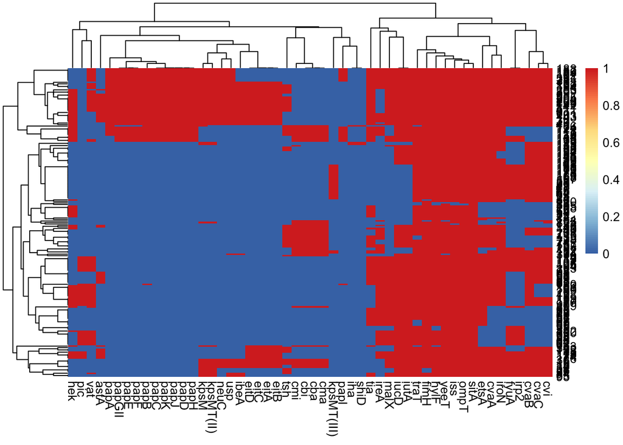

```r
vir_df <- BCO_APEC_simple_summary_N90L90 %>% dplyr::select(name, starts_with('vfdb'), starts_with('EC_'))

vir_df <- vir_df %>% column_to_rownames('name') %>% t() %>% as.data.frame()

vir_df <- vir_df %>% rownames_to_column('gene')

vir_df <- vir_df %>% mutate(gene = str_replace(gene, 'vfdb_|EC_custom_', ''))

vir_df <- vir_df %>% column_to_rownames('gene') %>% t()

vir_df[vir_df > 1] <- 1

vir_df <- as.data.frame(vir_df)

vir_df <- vir_df %>% dplyr::select(matches("astA"),
matches("cba"),
matches("celb"),
matches("cma"),
matches("cvaA"),
matches("cvaB"),
matches("cvaC"),
matches("cvi"),
matches("eilA"),
matches("eitA"),
matches("eitB"),
matches("eitC"),
matches("eitD"),
matches("etsA"),
matches("fimH"),
matches("fyuA"),
matches("gad"),
matches("gimB_marker"),
matches("hek"),
matches("hlyE"),
matches("hylF"),
matches("ibeA"),
matches("iha"),
matches("ipaH"),
matches("ireA"),
matches("iroN"),
matches("irp2"),
matches("iss"),
matches("iucD"),
matches("iutA"),
matches("kpsM"),
matches("kpsMT_II"),
matches("kpsMT_III"),
matches("lpfA"),
matches("malX"),
matches("mchB"),
matches("mchC"),
matches("mchF"),
matches("mcmA"),
matches("neuC"),
matches("ompT"),
matches("papA"),
matches("papB"),
matches("papC"),
matches("papD"),
matches("papE"),
matches("papF"),
matches("papGII"),
matches("papH"),
matches("papI"),
matches("papJ"),
matches("papK"),
matches("pic"),
matches("shiD"),
matches("sitA"),
matches("tia"),
matches("traT"),
matches("tsh"),
matches("usp"),
matches("vat"),
matches("yeeT")
)

vir_df <- vir_df %>%
        rowwise() %>%
        mutate(fimH_new= sum(fimH, fimH_CP015076.1, na.rm = T)) %>%
        dplyr::select(-fimH, -fimH_CP015076.1) %>%
        mutate(fyuA_new= sum(fyuA, fyuA_Z35106.1, na.rm = T)) %>%
        dplyr::select(-fyuA, -fyuA_Z35106.1) %>%
        mutate(ibeA_new= sum(ibeA, ibeA_AY248744.1, na.rm = T)) %>%
        dplyr::select(-ibeA, -ibeA_AY248744.1) %>%
        mutate(irp2_new = sum(irp2, `irp2_(gi:117624162)|VFG012550`, `irp2_(gi:218695586)|VFG034095`, `irp2_(gi:218705472)|VFG034101`, `irp2_(gi:222156713)|VFG034107`, `irp2_(gi:386629711)|VFG034099`, `irp2_(gi:387607663)|VFG034096`, `irp2_(gi:45441468)|VFG003119`, na.rm = T)) %>%
        dplyr::select(-irp2, -`irp2_(gi:117624162)|VFG012550`, -`irp2_(gi:218695586)|VFG034095`, -`irp2_(gi:218705472)|VFG034101`, -`irp2_(gi:222156713)|VFG034107`, -`irp2_(gi:386629711)|VFG034099`, -`irp2_(gi:387607663)|VFG034096`, -`irp2_(gi:45441468)|VFG003119`) %>%
        mutate(iss_new= sum(`iss_type2_ETEC-B7a_NZ_AAJT00000000`, iss_type3_UTI89_CP000243, na.rm = T)) %>%            dplyr::select(-`iss_type2_ETEC-B7a_NZ_AAJT00000000`, -iss_type3_UTI89_CP000243) %>%
        mutate(iucD_new = sum(iucD, iucD_AY545598.5, na.rm = T)) %>%
        dplyr::select(-iucD, -iucD_AY545598.5) %>%
        mutate(iutA_new = sum(iutA, iutA_KU578032.1, na.rm = T)) %>%
        dplyr::select(-iutA, -iutA_KU578032.1) %>%
        mutate(`kpsMT(II)_new` = sum(`kpsMT(II)_K1:AE014075.1|CFT073|3527848-3529293`, `kpsMT(II)_K2:CP000468.1:|APEC-O1|3376659-3378102`, `kpsMT(II)_K5:CP002212.1|3385642-3387090`, na.rm = T)) %>%
        dplyr::select(-`kpsMT(II)_K1:AE014075.1|CFT073|3527848-3529293`, -`kpsMT(II)_K2:CP000468.1:|APEC-O1|3376659-3378102`, -`kpsMT(II)_K5:CP002212.1|3385642-3387090`) %>%
        mutate(neuC_new = sum(neuC, neuC_CP007275.1, na.rm = T)) %>%
        dplyr::select(-neuC, -neuC_CP007275.1) %>%
        mutate(ompT_new = sum(`ompT_chromosomal_O157-H7_NC_002695`, `ompT_episomal_HM210637.1`, na.rm = T)) %>%
        dplyr::select(-`ompT_chromosomal_O157-H7_NC_002695`, -`ompT_episomal_HM210637.1`) %>%
        dplyr::select(-papB, -papD, -papE, -papF, -papH, -papI, -papJ, -papK)

vir_df <- vir_df %>% mutate(sitA_new = sum(`sitA_(gi:218704670)|VFG034199`, `sitA_(gi:387606979)|VFG034194`, `sitA_(gi:387616520)|VFG034206`, `sitA_(gi:82776740)|VFG013039`,  `sitA_(gi:88770314)|VFG012575`,  `sitA_(gi:91210366)|VFG012573`, na.RM = T)) %>% dplyr::select(-`sitA_(gi:218704670)|VFG034199`, -`sitA_(gi:387606979)|VFG034194`, -`sitA_(gi:387616520)|VFG034206`, -`sitA_(gi:82776740)|VFG013039`,  -`sitA_(gi:88770314)|VFG012575`,  -`sitA_(gi:91210366)|VFG012573`)

vir_df <- vir_df %>% mutate(papC_new = sum(papC, papC_CU928161)) %>% dplyr::select(-papC, -papC_CU928161)

vir_df <- vir_df %>% mutate(tia_new = sum(tia_CP019944.1, tia_CU928161)) %>% dplyr::select(-tia_CP019944.1, -tia_CU928161)

vir_df <- vir_df %>% mutate(usp_new = sum(usp_AB056434, usp_AB056436, usp_AB056437, usp_AB056439)) %>% dplyr::select(-usp_AB056434, -usp_AB056436, -usp_AB056437, -usp_AB056439)

vir_df <- vir_df %>% rename_all(funs(stringr::str_replace_all(., '_.*', '')))

vir_df[vir_df > 1] <- 1

heatmap_vir <- pheatmap(vir_df, cluster_cols = TRUE)
```

```r
vir_df <- vir_df %>% dplyr::select(all_of(heatmap_vir$tree_col$order))

binary_sum_perc_colnames <- function(df){
        df <- vir_df
        oldname <- colnames(df)
        n_w_gene <- colSums(df) %>% as.data.frame() %>% rownames_to_column('name') %>% rename('count' = '.')
        n_total <- nrow(df) %>% as.numeric()
        perc <- scales::percent(x = (n_w_gene$count/n_total), accuracy = 2)
        n_w_gene <- n_w_gene %>% mutate(count = as.character(count))
        n_total <- n_total %>% as.character(n_total)
        colnames(df) <- paste0(n_w_gene$name, " ", n_w_gene$count, "/", n_total, " (", perc, ")")
        return(df)
}

vir_df <- vir_df %>% binary_sum_perc_colnames()

vir_df <- vir_df %>% mutate(across(where(is.numeric), as.character))

vir_df <- vir_df %>% as.data.frame()

rownames(vir_df) <- BCO_APEC_simple_summary_N90L90$name



p2 <- gheatmap(
        p = p1_linear,
        data = vir_df,
        colnames_offset_y = -0.1,
        font.size = 3,
        hjust = 0,
        colnames = TRUE,
        colnames_position = "top",
        colnames_angle = 90,
        offset = 0.5,
        width = 15,
        color = rgb(220, 220, 220, max = 255, alpha = 50)
        ) +
theme(legend.position = "bottom",
        legend.box = "vertical",
        legend.key.size = unit(1, "mm"),
        legend.title = element_blank(),
        legend.text = element_text(size = 8)
        ) +
scale_color_manual(
        values = c(mycolslist, c('0' = 'white', '1' = 'red')),
        na.value = 'grey',
        guide = "none"
        ) +
scale_fill_manual(
        values = c(mycolslist, c('0' = 'white', '1' = 'red')),
        na.value = 'grey',

        ) +
        ylim(NA, 250)
```

## ColV Stats

```r
contingency_table_ColV_Collection <- table(genometa$Collection, genometa$ColV)

small_subset_tree <- read.tree("analysis/trees/old/mashtree_QC_pass_AVC_BCO_bone_nondup.tree")

small_subset_tree$tip.label <- gsub("\\.R1$","", small_subset_tree$tip.label)

small_subset_genometa <- genometa %>% filter(name %in% small_subset_tree$tip.label)

table(small_subset_genometa$Collection, small_subset_genometa$ColV) %>% chisq.test()
```

```
##
##  Chi-squared test for given probabilities
##
## data:  .
## X-squared = 44.182, df = 1, p-value = 2.992e-11
```

```r
chisq.test(contingency_table_ColV_Collection)
```

```
##
##  Chi-squared test for given probabilities
##
## data:  contingency_table_ColV_Collection
## X-squared = 114.19, df = 1, p-value < 2.2e-16
```